# Homework 8

## Data Setup/Creation

```r
set.seed(82)

## Two dataframes of related values
## Assists by position 2001 and 2021
## Mean/averages calculated from data on basketball-reference.com

## Centers
center_2001 <- rnorm(n = 100, mean = 0.83, sd = .3)
center_2021 <- rnorm(n = 100, mean = 1.6, sd = .4)

## Point Guards
pg_2001 <- abs(rnorm(n = 100, mean = 4.06, sd = 2)) ## abs so I can increase sd without getting negatives
pg_2021 <- abs(rnorm(n = 100, mean = 4.05, sd = 2))

## Shooting Guards
sg_2001 <- rnorm(n= 100, mean = 2.6, sd = .8)
sg_2021 <- rnorm(n = 100, mean = 2.2, sd = .7)

## Small Forwards
sf_2001 <- rnorm(n = 100, mean = 1.8, sd = .48)
sf_2021 <- rnorm(n = 100, mean = 1.9, sd = .5)

## Power Forwards
pf_2001 <- rnorm(n = 100, mean = 1.4, sd = .35)
pf_2021 <- rnorm(n = 100, mean = 1.8, sd = .45)
```

## More Cleaning

I needed additional transformations to graph the data as I intended.

```r
## Create dataframes from vectors


### Dataframes with no melt

## 2001 Assists
assists_2001 <- data.frame(center_2001, pg_2001, sg_2001, sf_2001, pf_2001)

## Rename Variables
assists_2001 <- assists_2001 %>%
  rename(
    Center = center_2001,
    Point_Guard = pg_2001,
    Shooting_Guard = sg_2001,
    Shooting_Forward = sf_2001,
    Power_Forward = pf_2001
  )

## 2021 Assists
assists_2021 <- data.frame(center_2021, pg_2021, sg_2021, sf_2021, pf_2021)

## Rename Variables
assists_2021 <- assists_2021 %>%
  rename(
    Center = center_2021,
    Point_Guard = pg_2021,
    Shooting_Guard = sg_2021,
    Shooting_Forward = sf_2021,
    Power_Forward = pf_2021
  )


## 2001 Assists Dataframe Melted
nba_assists_2001 <- melt(assists_2001)
colnames(nba_assists_2001) <- c('Position', 'APG')



## 2021 Assists Dataframe Melted
nba_assists_2021 <- melt(assists_2021)
colnames(nba_assists_2021) <- c('Position', 'APG')
```

## Graphical Analysis

I ran a pairs.panel on unaltered dataset to look for any correlations, and view the general distribution. There were no interesting associations of note. From here, I wanted to visualize the differences with a boxplot sequence. In this, there are three `Positions` that appear to have significant movement from 2001 to 2021; `Center`, `Shooting Guard`, and `Power Foward`. `Point Guard` also seems to have increased over the years in variance.  
Additionally, I tallied the Assist Totals and multiplied them by 82 games (Season length), to get the Season totals for Assists. This is represented in the bar chart, which demonstrates a rise in assists from 2001 to 2021.

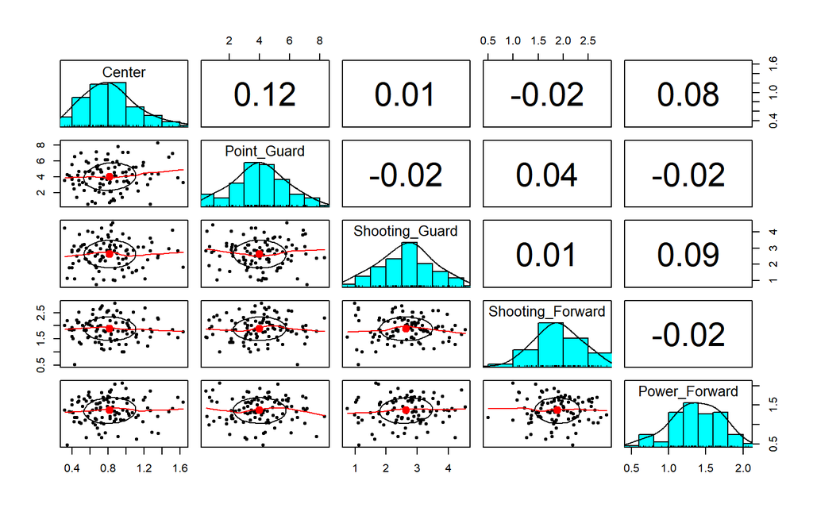

```r
## Assists 2001
pairs.panels(assists_2001)
```

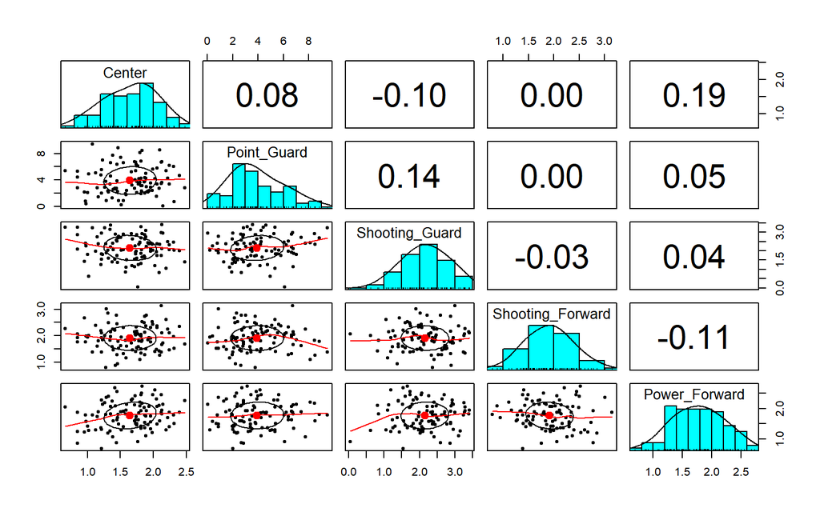

```r
## Assists 2021
pairs.panels(assists_2021)
```

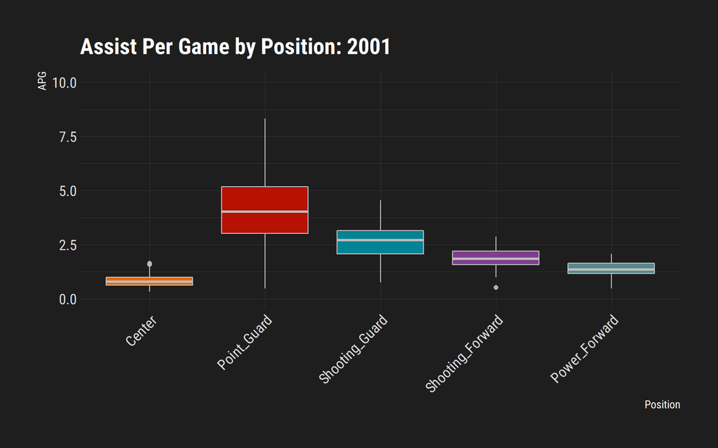

```r
# 2001 Boxplot
g1 <- ggplot(data = nba_assists_2001,
       mapping = aes(x = Position, y = APG, fill = Position))+
  geom_boxplot(alpha = .9, color = 'grey')+
  scale_fill_futurama()+
  labs(title = 'Assist Per Game by Position: 2001')+
  guides(fill = FALSE)+
  ylim(0,10)+
  theme_modern_rc()+
  theme(axis.text.x = element_text(angle = 45, hjust = 1))

# 2021 Boxplot
g2 <- ggplot(data = nba_assists_2021,
       mapping = aes(x = Position, y = APG, fill = Position))+
  geom_boxplot(alpha = .9, color = 'grey')+
  scale_fill_futurama()+
  labs(title = 'Assist Per Game by Position: 2021')+
  guides(fill = FALSE)+
  ylim(0,10)+
  theme_modern_rc()+
  theme(axis.text.x = element_text(angle = 45, hjust = 1))

# 2001 Boxplot Print
g1
```

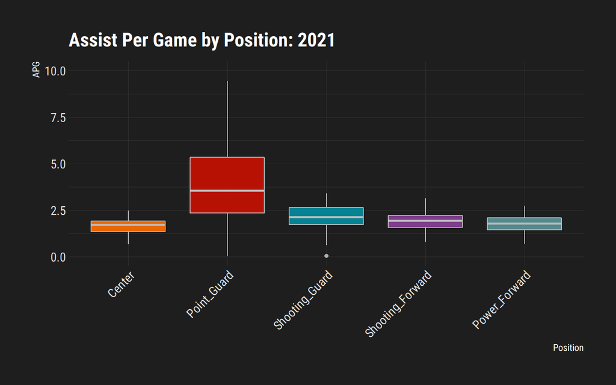

```r
# 2021 Boxplot Print
g2
```

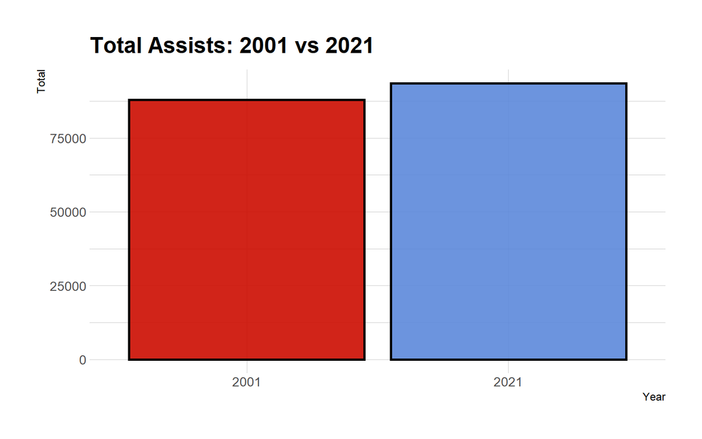

```r
## Total Assist Comparison
total_2001 <- sum(nba_assists_2001$APG * 82)
total_2021 <- sum(nba_assists_2021$APG * 82)

total_assists <- data.frame(total_2001, total_2021)

nba_total_assists <- melt(total_assists)
colnames(nba_total_assists) <- c('Year', 'Total')

ggplot(data = nba_total_assists,
       mapping = aes(x = Year, y = Total, fill = Year))+
  geom_col(position = 'dodge', color = 'black', size = 1, alpha = .9)+
  guides(fill = FALSE)+
  scale_fill_startrek()+
  theme_ipsum_tw()+
  labs(title = "Total Assists: 2001 vs 2021")+
  scale_x_discrete(labels = c('2001', '2021'))
```

## Further Cleaning

More cleaning to set up t.tests

```r
## 2001 vs 2021 Positions

## Center
center_data <- assists_2001 %>%
  select(Center)
center_data[2] <- assists_2021 %>%
  select(Center)

center_data <- center_data %>%
  rename(
    C_2001 = Center,
    C_2021 = Center.1)

## PG
pg_data <- assists_2001 %>%
  select(Point_Guard)
pg_data[2] <- assists_2021 %>%
  select(Point_Guard)

pg_data <- pg_data %>%
  rename(
    PG_2001 = Point_Guard,
    PG_2021 = Point_Guard.1)


## SG
sg_data <- assists_2001 %>%
  select(Shooting_Guard)
sg_data[2] <- assists_2021 %>%
  select(Shooting_Guard)

sg_data <- sg_data %>%
  rename(
    SG_2001 = Shooting_Guard,
    SG_2021 = Shooting_Guard.1)


## SF
sf_data <- assists_2001 %>%
  select(Shooting_Forward)
sf_data[2] <- assists_2021 %>%
  select(Shooting_Forward)

sf_data <- sf_data %>%
  rename(
    SF_2001 = Shooting_Forward,
    SF_2021 = Shooting_Forward.1)


## PF
pf_data <- assists_2001 %>%
  select(Power_Forward)
pf_data[2] <- assists_2021 %>%
  select(Power_Forward)

pf_data <- pf_data %>%
  rename(
    PF_2001 = Power_Forward,
    PF_2021 = Power_Forward.1)
```

## t.test

We saw there was a visual difference in some of the assists in the boxplots, but was there a statistically significant difference? To test this, I ran a t.test; conditions are (mostly) normal (I have abs() on point_guard to prevent negative outliers). The t.test confirmed the visual analysis; there was a statistically significant difference in the means in Assists per Game for `Center`, `Shooting_Guard`, and `Power_Forward`. The direction of the difference aligns with our hypothesis - it would appear that Assists per Game have increased in the power positions.

```r
## Center t.test
t.test(center_data$C_2001, center_data$C_2021)
```

```
##
##  Welch Two Sample t-test
##
## data:  center_data$C_2001 and center_data$C_2021
## t = -16.867, df = 180.31, p-value < 2.2e-16
## alternative hypothesis: true difference in means is not equal to 0
## 95 percent confidence interval:
##  -0.9253784 -0.7315461
## sample estimates:
## mean of x mean of y
## 0.8180269 1.6464892
```

```r
## PG t.test
t.test(pg_data$PG_2001, pg_data$PG_2021)
```

```
##
##  Welch Two Sample t-test
##
## data:  pg_data$PG_2001 and pg_data$PG_2021
## t = 0.32014, df = 191.59, p-value = 0.7492
## alternative hypothesis: true difference in means is not equal to 0
## 95 percent confidence interval:
##  -0.4512645  0.6261382
## sample estimates:
## mean of x mean of y
##  4.014422  3.926985
```

```r
## SG t.test
t.test(sg_data$SG_2001, sg_data$SG_2021)
```

```
##
##  Welch Two Sample t-test
##
## data:  sg_data$SG_2001 and sg_data$SG_2021
## t = 4.5039, df = 187.94, p-value = 1.17e-05
## alternative hypothesis: true difference in means is not equal to 0
## 95 percent confidence interval:
##  0.2753868 0.7046292
## sample estimates:
## mean of x mean of y
##  2.639635  2.149627
```

```r
## SF t.test
t.test(sf_data$SF_2001, sf_data$SF_2021)
```

```
##
##  Welch Two Sample t-test
##
## data:  sf_data$SF_2001 and sf_data$SF_2021
## t = -0.48748, df = 197.76, p-value = 0.6265
## alternative hypothesis: true difference in means is not equal to 0
## 95 percent confidence interval:
##  -0.15950358  0.09627588
## sample estimates:
## mean of x mean of y
##  1.883242  1.914856
```

```r
## PF t.test
t.test(pf_data$PF_2001, pf_data$PF_2021)
```

```
##
##  Welch Two Sample t-test
##
## data:  pf_data$PF_2001 and pf_data$PF_2021
## t = -7.3542, df = 184.53, p-value = 6.076e-12
## alternative hypothesis: true difference in means is not equal to 0
## 95 percent confidence interval:
##  -0.5137739 -0.2964222
## sample estimates:
## mean of x mean of y
##  1.365262  1.770360
```

## Change the Numbers

```r
## Change the numbers to alter results

## Centers
center_2001 <- rnorm(n = 10, mean = 0.83, sd = .3)
center_2021 <- rnorm(n = 10, mean = 2.6, sd = .4)

## Point Guards
pg_2001 <- abs(rnorm(n = 100, mean = 4.06, sd = 2)) ## abs so I can increase sd without getting negatives
pg_2021 <- abs(rnorm(n = 100, mean = 5.05, sd = 4))

## Shooting Guards
sg_2001 <- rnorm(n= 200, mean = 2.6, sd = .8)
sg_2021 <- rnorm(n = 200, mean = 2.2, sd = .7)

## Small Forwards
sf_2001 <- rnorm(n = 100, mean = 5.8, sd = .48)
sf_2021 <- rnorm(n = 100, mean = 1.9, sd = .5)

## Power Forwards
pf_2001 <- rnorm(n = 50, mean = 1.6, sd = .35)
pf_2021 <- rnorm(n = 50, mean = 1.8, sd = .45)


## Reload All Transformations


### Dataframes with no melt

## 2001 Assists
assists_2001 <- data.frame(center_2001, pg_2001, sg_2001, sf_2001, pf_2001)

## Rename Variables
assists_2001 <- assists_2001 %>%
  rename(
    Center = center_2001,
    Point_Guard = pg_2001,
    Shooting_Guard = sg_2001,
    Shooting_Forward = sf_2001,
    Power_Forward = pf_2001
  )

## 2021 Assists
assists_2021 <- data.frame(center_2021, pg_2021, sg_2021, sf_2021, pf_2021)

## Rename Variables
assists_2021 <- assists_2021 %>%
  rename(
    Center = center_2021,
    Point_Guard = pg_2021,
    Shooting_Guard = sg_2021,
    Shooting_Forward = sf_2021,
    Power_Forward = pf_2021
  )


## 2001 Assists Dataframe Melted
nba_assists_2001 <- melt(assists_2001)
colnames(nba_assists_2001) <- c('Position', 'APG')



## 2021 Assists Dataframe Melted
nba_assists_2021 <- melt(assists_2021)
colnames(nba_assists_2021) <- c('Position', 'APG')


## 2001 vs 2021 Positions

## Center
center_data <- assists_2001 %>%
  select(Center)
center_data[2] <- assists_2021 %>%
  select(Center)

center_data <- center_data %>%
  rename(
    C_2001 = Center,
    C_2021 = Center.1)

## PG
pg_data <- assists_2001 %>%
  select(Point_Guard)
pg_data[2] <- assists_2021 %>%
  select(Point_Guard)

pg_data <- pg_data %>%
  rename(
    PG_2001 = Point_Guard,
    PG_2021 = Point_Guard.1)


## SG
sg_data <- assists_2001 %>%
  select(Shooting_Guard)
sg_data[2] <- assists_2021 %>%
  select(Shooting_Guard)

sg_data <- sg_data %>%
  rename(
    SG_2001 = Shooting_Guard,
    SG_2021 = Shooting_Guard.1)


## SF
sf_data <- assists_2001 %>%
  select(Shooting_Forward)
sf_data[2] <- assists_2021 %>%
  select(Shooting_Forward)

sf_data <- sf_data %>%
  rename(
    SF_2001 = Shooting_Forward,
    SF_2021 = Shooting_Forward.1)


## PF
pf_data <- assists_2001 %>%
  select(Power_Forward)
pf_data[2] <- assists_2021 %>%
  select(Power_Forward)

pf_data <- pf_data %>%
  rename(
    PF_2001 = Power_Forward,
    PF_2021 = Power_Forward.1)
```

## Altered t.test

Changing the numbers drastically effects the t.test, which was to be expected.

```r
## Center t.test
t.test(center_data$C_2001, center_data$C_2021)
```

```
##
##  Welch Two Sample t-test
##
## data:  center_data$C_2001 and center_data$C_2021
## t = -72.73, df = 389.66, p-value < 2.2e-16
## alternative hypothesis: true difference in means is not equal to 0
## 95 percent confidence interval:
##  -1.755899 -1.663465
## sample estimates:
## mean of x mean of y
## 0.8576073 2.5672893
```

```r
## PG t.test
t.test(pg_data$PG_2001, pg_data$PG_2021)
```

```
##
##  Welch Two Sample t-test
##
## data:  pg_data$PG_2001 and pg_data$PG_2021
## t = -1.1773, df = 314.96, p-value = 0.24
## alternative hypothesis: true difference in means is not equal to 0
## 95 percent confidence interval:
##  -0.9125655  0.2293206
## sample estimates:
## mean of x mean of y
##  4.520038  4.861661
```

```r
## SG t.test
t.test(sg_data$SG_2001, sg_data$SG_2021)
```

```
##
##  Welch Two Sample t-test
##
## data:  sg_data$SG_2001 and sg_data$SG_2021
## t = 5.036, df = 391.84, p-value = 7.266e-07
## alternative hypothesis: true difference in means is not equal to 0
## 95 percent confidence interval:
##  0.2282941 0.5206962
## sample estimates:
## mean of x mean of y
##  2.530148  2.155653
```

```r
## SF t.test
t.test(sf_data$SF_2001, sf_data$SF_2021)
```

```
##
##  Welch Two Sample t-test
##
## data:  sf_data$SF_2001 and sf_data$SF_2021
## t = 74.794, df = 389.24, p-value < 2.2e-16
## alternative hypothesis: true difference in means is not equal to 0
## 95 percent confidence interval:
##  3.885583 4.095375
## sample estimates:
## mean of x mean of y
##  5.879501  1.889022
```

```r
## PF t.test
t.test(pf_data$PF_2001, pf_data$PF_2021)
```

```
##
##  Welch Two Sample t-test
##
## data:  pf_data$PF_2001 and pf_data$PF_2021
## t = -1.4348, df = 371.2, p-value = 0.1522
## alternative hypothesis: true difference in means is not equal to 0
## 95 percent confidence interval:
##  -0.12953020  0.02024663
## sample estimates:
## mean of x mean of y
##  1.653074  1.707715
```